# Data Analysis for Congressional Tweets

**Author: Yamei Song**

I get the congressional tweets dataset from Lobbyists4America. I take Lobbyists4America as my hypothetical client. In order to help my client focus and strengthen his/her lobbying efforts, I will find the key topics, members, and relationships within Congress from this dataset.

# ERD

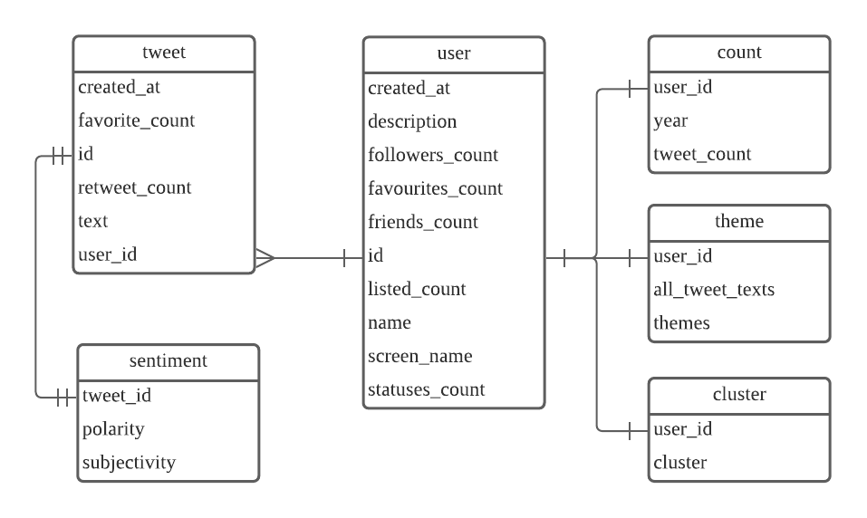

# Hypothesis

1. **What are the key topics of those congressional tweets and how often?**

   Can be inferred from tweet texts.

   Key topics maybe health, education, technology, and alike.
1. **Who publishes congressional tweets and how often?**

   Will count a user’s tweets in each year.

   Maybe the time to publish a tweet affects its favourites.

   Maybe the more frequent a user publishes tweets, the more average favourites he/she gets.
1. **What are the relationships between people who publish congressional tweets?**

   Users will be divided into clusters according to their political views.

# Data Analysis Approach

- **Will extract entities from tweet texts and look at entity count/frequency**

  For topic analysis.
- **Will look at frequency metrics**

  For frequency of posting tweets during a time period.
- **Will use machine learning models**

  For sentiment analysis of tweet texts.

  For clustering like-minded tweeters.

```python
import pandas as pd
import numpy as np
import seaborn as sns
import matplotlib.pyplot as plt
from textblob import TextBlob
```

# Read and compress raw files

## Read JSON files

Since *tweets.json* is too large, it must be separated to many chunks and then read.

```python
reader_tweets = pd.read_json('./tweets.json', lines=True, chunksize=1000)

dfs = list()

for chunk in reader_tweets:
    dfs.append(chunk)

df_tweets = pd.concat(dfs)
```

```python
df_users = pd.read_json('./users.json', lines=True)
```

## Save DataFrames as pickle files

pickle file is smaller and faster to read.

```python
df_tweets.to_pickle('./df_tweets.pkl')
```

```python
df_users.to_pickle('./df_users.pkl')
```

# Clean data

## Read pickle files

```python
df_tweets = pd.read_pickle('./df_tweets.pkl')
df_tweets.head()
```

|  | contributors | coordinates | created_at | display_text_range | entities | favorite_count | favorited | geo | id | id_str | ... | text | truncated | user_id | possibly_sensitive | extended_entities | quoted_status_id | quoted_status_id_str | withheld_copyright | withheld_in_countries | withheld_scope |
| --- | --- | --- | --- | --- | --- | --- | --- | --- | --- | --- | --- | --- | --- | --- | --- | --- | --- | --- | --- | --- | --- |
| 0 | NaN | NaN | 2008-08-04 17:28:51 | [0, 74] | {'hashtags': [], 'symbols': [], 'urls': [], 'u... | 0 | False | NaN | 877418565 | 877418565 | ... | On a conference call about a weekend trip to I... | False | 5558312 | NaN | NaN | NaN | NaN | NaN | NaN | NaN |
| 1 | NaN | NaN | 2008-08-06 19:04:45 | [0, 25] | {'hashtags': [], 'symbols': [], 'urls': [], 'u... | 0 | False | NaN | 879618172 | 879618172 | ... | Being interviewed by KTHV | False | 5558312 | NaN | NaN | NaN | NaN | NaN | NaN | NaN |
| 2 | NaN | NaN | 2008-08-06 20:35:36 | [0, 65] | {'hashtags': [], 'symbols': [], 'urls': [], 'u... | 0 | False | NaN | 879695803 | 879695803 | ... | Being interviewed by KARN on his Arkansas Worl... | False | 5558312 | NaN | NaN | NaN | NaN | NaN | NaN | NaN |
| 3 | NaN | NaN | 2008-08-07 13:52:52 | [0, 37] | {'hashtags': [], 'symbols': [], 'urls': [], 'u... | 0 | False | NaN | 880393665 | 880393665 | ... | On KWHN in Fort Smith, that's 1320 AM | False | 5558312 | NaN | NaN | NaN | NaN | NaN | NaN | NaN |
| 4 | NaN | NaN | 2008-08-07 15:12:05 | [0, 90] | {'hashtags': [], 'symbols': [], 'urls': [], 'u... | 0 | False | NaN | 880474266 | 880474266 | ... | Attending a Military of the Purple Heart Cerem... | False | 5558312 | NaN | NaN | NaN | NaN | NaN | NaN | NaN |

5 rows × 32 columns

```python
df_users = pd.read_pickle('./df_users.pkl')
df_users.head()
```

|  | contributors_enabled | created_at | default_profile | default_profile_image | description | entities | favourites_count | follow_request_sent | followers_count | following | ... | profile_text_color | profile_use_background_image | protected | screen_name | statuses_count | time_zone | translator_type | url | utc_offset | verified |
| --- | --- | --- | --- | --- | --- | --- | --- | --- | --- | --- | --- | --- | --- | --- | --- | --- | --- | --- | --- | --- | --- |
| 0 | False | 1970-01-01 00:00:01.417384037+00:00 | True | False | Official Twitter page of Alaska Governor Bill ... | {'description': {'urls': []}, 'url': {'urls': ... | 115 | False | 5870 | False | ... | 333333 | True | False | AkGovBillWalker | 1642 | None | none | http://t.co/NO67LyZvUR | NaN | True |
| 1 | False | 1970-01-01 00:00:01.240239576+00:00 | False | False | U.S. Senator from Minnesota. Follows, Retweets... | {'description': {'urls': []}, 'url': {'urls': ... | 24 | False | 170717 | False | ... | 3D3C3D | True | False | amyklobuchar | 5567 | Central Time (US & Canada) | none | http://t.co/mGGFBfggto | -18000.0 | True |
| 2 | False | 1970-01-01 00:00:01.366837593+00:00 | False | False | Congressman for Maryland's 4th Congressional D... | {'description': {'urls': []}, 'url': {'urls': ... | 90 | False | 6067 | False | ... | 333333 | False | False | AnthonyBrownMD4 | 1878 | Eastern Time (US & Canada) | none | https://t.co/NYPWOVmoAx | -14400.0 | True |
| 3 | False | 1970-01-01 00:00:01.300739574+00:00 | False | False | Husband of 43 yrs, Dad of 4, Papaw of 6. Lifel... | {'description': {'urls': []}, 'url': {'urls': ... | 440 | False | 25747 | False | ... | 333333 | False | False | AsaHutchinson | 3778 | Central Time (US & Canada) | none | https://t.co/b38CUNlZHi | -18000.0 | True |
| 4 | False | 1970-01-01 00:00:01.294329706+00:00 | False | False | I am proud to represent the 8th Congressional ... | {'description': {'urls': []}, 'url': {'urls': ... | 12 | False | 13048 | False | ... | 11172E | True | False | AustinScottGA08 | 2022 | None | none | http://t.co/GQwXIhub9a | NaN | True |

5 rows × 42 columns

## Inspect data

```python
df_tweets.info()
```

```
<class 'pandas.core.frame.DataFrame'>
RangeIndex: 1243370 entries, 0 to 1243369
Data columns (total 32 columns):
 #   Column                     Non-Null Count    Dtype
---  ------                     --------------    -----
 0   contributors               0 non-null        float64
 1   coordinates                2734 non-null     object
 2   created_at                 1243370 non-null  datetime64[ns]
 3   display_text_range         1243370 non-null  object
 4   entities                   1243370 non-null  object
 5   favorite_count             1243370 non-null  int64
 6   favorited                  1243370 non-null  bool
 7   geo                        2734 non-null     object
 8   id                         1243370 non-null  int64
 9   id_str                     1243370 non-null  int64
```

[output cut: 24 more lines]

```python
df_users.info()
```

```
<class 'pandas.core.frame.DataFrame'>
RangeIndex: 548 entries, 0 to 547
Data columns (total 42 columns):
 #   Column                              Non-Null Count  Dtype
---  ------                              --------------  -----
 0   contributors_enabled                548 non-null    bool
 1   created_at                          548 non-null    datetime64[ns, UTC]
 2   default_profile                     548 non-null    bool
 3   default_profile_image               548 non-null    bool
 4   description                         548 non-null    object
 5   entities                            545 non-null    object
 6   favourites_count                    548 non-null    int64
 7   follow_request_sent                 548 non-null    bool
 8   followers_count                     548 non-null    int64
 9   following                           548 non-null    bool
```

[output cut: 34 more lines]

## Delete null/minor/duplicate/useless columns

- Null columns: most values are null/none.
- Minor columns: number of values is much smaller than the total number of rows.
- Duplicate columns: values are duplicate of values in another column, such as **id** and **id_str**.
- Useless columns: such as **time_zone, profile_image_url** ...

```python
df_tweets_cleaned = df_tweets[['created_at',
                               'favorite_count',
                               'id',
                               'retweet_count',
                               'text',
                               'user_id']]
df_tweets_cleaned.head()
```

|  | created_at | favorite_count | id | retweet_count | text | user_id |
| --- | --- | --- | --- | --- | --- | --- |
| 0 | 2008-08-04 17:28:51 | 0 | 877418565 | 0 | On a conference call about a weekend trip to I... | 5558312 |
| 1 | 2008-08-06 19:04:45 | 0 | 879618172 | 0 | Being interviewed by KTHV | 5558312 |
| 2 | 2008-08-06 20:35:36 | 0 | 879695803 | 0 | Being interviewed by KARN on his Arkansas Worl... | 5558312 |
| 3 | 2008-08-07 13:52:52 | 0 | 880393665 | 0 | On KWHN in Fort Smith, that's 1320 AM | 5558312 |
| 4 | 2008-08-07 15:12:05 | 0 | 880474266 | 0 | Attending a Military of the Purple Heart Cerem... | 5558312 |

```python
df_users_cleaned = df_users[['created_at',
                             'description',
                             'followers_count',
                             'favourites_count',
                             'friends_count',
                             'id',
                             'listed_count',
                             'name',
                             'screen_name',
                             'statuses_count']]
df_users_cleaned.head()
```

|  | created_at | description | followers_count | favourites_count | friends_count | id | listed_count | name | screen_name | statuses_count |
| --- | --- | --- | --- | --- | --- | --- | --- | --- | --- | --- |
| 0 | 1970-01-01 00:00:01.417384037+00:00 | Official Twitter page of Alaska Governor Bill ... | 5870 | 115 | 550 | 2915095729 | 190 | Governor Bill Walker | AkGovBillWalker | 1642 |
| 1 | 1970-01-01 00:00:01.240239576+00:00 | U.S. Senator from Minnesota. Follows, Retweets... | 170717 | 24 | 91751 | 33537967 | 2493 | Amy Klobuchar | amyklobuchar | 5567 |
| 2 | 1970-01-01 00:00:01.366837593+00:00 | Congressman for Maryland's 4th Congressional D... | 6067 | 90 | 369 | 1378000346 | 170 | Anthony G. Brown | AnthonyBrownMD4 | 1878 |
| 3 | 1970-01-01 00:00:01.300739574+00:00 | Husband of 43 yrs, Dad of 4, Papaw of 6. Lifel... | 25747 | 440 | 598 | 269992801 | 420 | Gov. Asa Hutchinson | AsaHutchinson | 3778 |
| 4 | 1970-01-01 00:00:01.294329706+00:00 | I am proud to represent the 8th Congressional ... | 13048 | 12 | 313 | 234797704 | 735 | Rep. Austin Scott | AustinScottGA08 | 2022 |

## Save cleaned data as pickle files

```python
df_tweets_cleaned.to_pickle('./df_tweets_cleaned.pkl')
```

```python
df_users_cleaned.to_pickle('./df_users_cleaned.pkl')
```

# Explore data

## Read cleaned data from pickle files

```python
df_tweets = pd.read_pickle('./df_tweets_cleaned.pkl')
df_users = pd.read_pickle('./df_users_cleaned.pkl')
```

## Description and distribution of data

```python
df_tweets.describe()
```

|  | favorite_count | id | retweet_count | user_id |
| --- | --- | --- | --- | --- |
| count | 1.243370e+06 | 1.243370e+06 | 1.243370e+06 | 1.243370e+06 |
| mean | 2.008517e+02 | 6.096596e+17 | 1.900628e+02 | 1.397405e+16 |
| std | 3.545405e+03 | 2.140925e+17 | 9.944392e+03 | 1.053383e+17 |
| min | 0.000000e+00 | 8.774186e+08 | 0.000000e+00 | 5.558312e+06 |
| 25% | 0.000000e+00 | 4.767952e+17 | 1.000000e+00 | 3.375080e+07 |
| 50% | 2.000000e+00 | 6.623818e+17 | 4.000000e+00 | 2.340223e+08 |
| 75% | 8.000000e+00 | 7.812416e+17 | 1.000000e+01 | 9.931530e+08 |
| max | 9.848320e+05 | 8.721400e+17 | 3.637896e+06 | 8.547151e+17 |

### Conclusion 1

Still, there are some tweets have very high *favorite_count* (max: 9.848320e+05) and *retweet_count* (max: 3.637896e+06).

```python
df_users.describe()
```

|  | followers_count | favourites_count | friends_count | id | listed_count | statuses_count |
| --- | --- | --- | --- | --- | --- | --- |
| count | 5.480000e+02 | 548.000000 | 548.000000 | 5.480000e+02 | 548.000000 | 548.000000 |
| mean | 1.634339e+05 | 413.912409 | 2033.731752 | 7.236303e+16 | 1340.647810 | 3658.959854 |
| std | 1.597357e+06 | 965.151440 | 6278.436076 | 2.312213e+17 | 3567.588267 | 4259.273134 |
| min | 4.000000e+00 | 0.000000 | 0.000000 | 5.558312e+06 | 0.000000 | 0.000000 |
| 25% | 8.960250e+03 | 32.750000 | 368.000000 | 5.768882e+07 | 426.750000 | 1387.500000 |
| 50% | 1.673200e+04 | 120.500000 | 751.500000 | 2.470519e+08 | 750.000000 | 2684.000000 |
| 75% | 3.308100e+04 | 379.750000 | 1670.500000 | 1.212627e+09 | 1257.000000 | 4509.250000 |
| max | 3.171258e+07 | 12507.000000 | 92934.000000 | 8.547151e+17 | 70660.000000 | 59535.000000 |

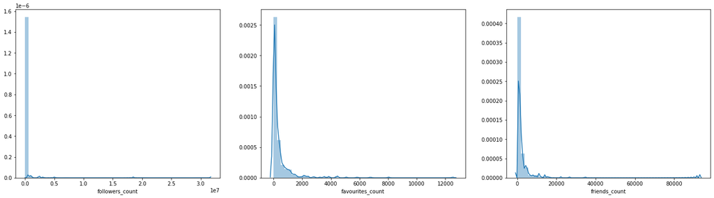

```python
fig, (ax1, ax2, ax3) = plt.subplots(1, 3, figsize = (24, 6))
sns.distplot(df_users['followers_count'], ax=ax1)
sns.distplot(df_users['favourites_count'], ax=ax2)
sns.distplot(df_users['friends_count'], ax=ax3)
```

### Conclusion 2

The statistics and graphs of *df_users* shows that only a few users have a large number of followers, favorites, and friends.

Let's see who are the political celebrities in tweeter!

```python
df_users\
.sort_values('followers_count', ascending=False)\
[['name', 'followers_count']]\
.reset_index(drop=True)
```

|  | name | followers_count |
| --- | --- | --- |
| 0 | Donald J. Trump | 31712585 |
| 1 | President Trump | 18545354 |
| 2 | Bernie Sanders | 5072538 |
| 3 | Cory Booker | 3094413 |
| 4 | Marco Rubio | 2554822 |
| ... | ... | ... |
| 543 | U.S.Rep Gonzalez | 437 |
| 544 | Greg Harper | 41 |
| 545 | Yvette Clarke | 41 |
| 546 | tiberipress | 23 |
| 547 | Jasmine Coleman | 4 |

548 rows × 2 columns

## Who are the most active users?

Create a dataframe *df_count* that stores the number of users' tweets in each year.

```python
df_tweets['year'] = df_tweets['created_at'].dt.year
df_tweet_count = df_tweets.groupby(['user_id', 'year'])['id'].count().to_frame('count').reset_index()
df_count = df_tweet_count.merge(df_users[['id', 'name']], how='left', left_on='user_id', right_on='id')
df_count.drop('id', axis=1, inplace=True)
df_count.head()
```

|  | user_id | year | count | name |
| --- | --- | --- | --- | --- |
| 0 | 5558312 | 2008 | 44 | Senator John Boozman |
| 1 | 5558312 | 2009 | 160 | Senator John Boozman |
| 2 | 5558312 | 2010 | 80 | Senator John Boozman |
| 3 | 5558312 | 2011 | 267 | Senator John Boozman |
| 4 | 5558312 | 2012 | 250 | Senator John Boozman |

### Top 10 active users in 2016

1. Filter rows where "year==2016"
2. Descendingly sort the rows by "count"

```python
df_count[df_count['year'] == 2016]\
.sort_values('count', ascending=False)\
.reset_index(drop=True).head(10)
```

|  | user_id | year | count | name |
| --- | --- | --- | --- | --- |
| 0 | 2612307559 | 2016 | 3233 | Rob Portman |
| 1 | 18020081 | 2016 | 2567 | John Kasich |
| 2 | 3122099613 | 2016 | 2514 | Donald Norcross |
| 3 | 193441812 | 2016 | 2431 | Pramila Jayapal |
| 4 | 25073877 | 2016 | 2401 | Donald J. Trump |
| 5 | 240778059 | 2016 | 2400 | Gina Raimondo |
| 6 | 72198806 | 2016 | 2388 | Kirsten Gillibrand |
| 7 | 968650362 | 2016 | 2295 | Tom Cotton |
| 8 | 18909919 | 2016 | 2295 | Jim Langevin |
| 9 | 33576489 | 2016 | 2255 | Brian Higgins |

### Top 10 active users in 2017

```python
df_count[df_count['year'] == 2017]\
.sort_values('count', ascending=False)\
.reset_index(drop=True).head(10)
```

|  | user_id | year | count | name |
| --- | --- | --- | --- | --- |
| 0 | 2962868158 | 2017 | 2727 | Rep. Don Beyer |
| 1 | 14275291 | 2017 | 2204 | Ileana Ros-Lehtinen |
| 2 | 15808765 | 2017 | 1835 | Cory Booker |
| 3 | 21406834 | 2017 | 1794 | Ed Markey |
| 4 | 806906355214852096 | 2017 | 1705 | Rep. Jamie Raskin |
| 5 | 2978837542 | 2017 | 1701 | Governor Tom Wolf |
| 6 | 171598736 | 2017 | 1669 | Senator Bob Casey |
| 7 | 17494010 | 2017 | 1630 | Chuck Schumer |
| 8 | 14135426 | 2017 | 1611 | Rep. Keith Ellison |
| 9 | 20217019 | 2017 | 1556 | Doug Ducey |

```python
# save df_count as pickle file
df_count.to_pickle('./df_count.pkl')
```

## Sentiment analysis

Use TextBlob to perform [sentiment analysis](https://textblob.readthedocs.io/en/dev/quickstart.html#sentiment-analysis).

```python
from nltk.book import *
```

[output not shown]

```python
def sentiment_analysis(text):

    # return a tuple (polarity, subjectivity)

    blob = TextBlob(text)

    return (blob.sentiment.polarity, blob.sentiment.subjectivity)
```

```python
df_tweets['polarity'] = np.nan
df_tweets['subjectivity'] = np.nan

df_tweets[['polarity', 'subjectivity']] = pd.DataFrame(
    df_tweets['text'].apply(sentiment_analysis).tolist(),
    index=df_tweets.index
)
df_tweets.head()
```

|  | created_at | favorite_count | id | retweet_count | text | user_id | polarity | subjectivity |
| --- | --- | --- | --- | --- | --- | --- | --- | --- |
| 0 | 2008-08-04 17:28:51 | 0 | 877418565 | 0 | On a conference call about a weekend trip to I... | 5558312 | 0.000000 | 0.000000 |
| 1 | 2008-08-06 19:04:45 | 0 | 879618172 | 0 | Being interviewed by KTHV | 5558312 | 0.000000 | 0.000000 |
| 2 | 2008-08-06 20:35:36 | 0 | 879695803 | 0 | Being interviewed by KARN on his Arkansas Worl... | 5558312 | -0.100000 | 0.100000 |
| 3 | 2008-08-07 13:52:52 | 0 | 880393665 | 0 | On KWHN in Fort Smith, that's 1320 AM | 5558312 | 0.000000 | 0.000000 |
| 4 | 2008-08-07 15:12:05 | 0 | 880474266 | 0 | Attending a Military of the Purple Heart Cerem... | 5558312 | -0.066667 | 0.066667 |

```python
# save df_tweets as pickle file
df_tweets.to_pickle('./df_tweets_sentiment.pkl')
```

### Sentiment of "Obama" and "Trump"

```python
# will use "time" to calculate the mean sentiment by date
df_tweets['time'] = pd.to_datetime(
    df_tweets['created_at'].dt.strftime('%m/%Y')
)
```

```python
# filter rows that contains 'obama' in the text
df_tweets_obama = df_tweets[
    df_tweets['text'].str.contains('obama', case=False, regex=True)
]

# calculate mean polarity of text containing 'obama'
df_obama_sentiment = df_tweets_obama.groupby('time')['polarity'].mean().reset_index()

df_obama_sentiment['label'] = 'obama'
```

```python
# filter rows that contains 'trump' in the text
df_tweets_trump = df_tweets[
    df_tweets['text'].str.contains('trump', case=False, regex=True)
]

# calculate the mean polarity of text containing 'trump' by time
df_trump_sentiment = df_tweets_trump.groupby('time')['polarity'].mean().reset_index()

df_trump_sentiment['label'] = 'trump'
```

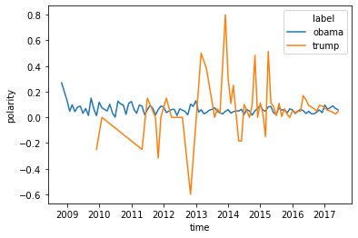

```python
# concat two dataframes
df_sentiment = pd.concat([df_obama_sentiment, df_trump_sentiment])

# line plot
sns.lineplot(data=df_sentiment, x='time', y='polarity', hue='label')
```

It turns out that people had been holding positive views of Obama from 2009 to 2017.

By contrast, people's attitude toward Trump had changed dramatically. Between 2013 and 2014, there was an interesting shift of sentiment from negative to positive.

> Tip: **Polarity** ranges from -1 to 1. Negative value means negative attitude. Positive value means positive attitude.

## Theme extraction

Since each tweet is pretty short and lacks information, themes are extracted from all tweets of each user.

Steps:

1. Group the tweets by user_id.
2. Combine all tweet texts of one user together.
3. Clean the text by removing some signs (#'"/).
4. Use TextBlob to [extract entities](https://textblob.readthedocs.io/en/dev/advanced_usage.html#noun-phrase-chunkers) from texts.

In this way, I get the themes that a user is mostly interested in.

```python
from textblob.np_extractors import ConllExtractor
import collections

def extract_themes(text):

    # extract entities
    extractor = ConllExtractor()
    blob = TextBlob(text, np_extractor=extractor)
    entities = list(blob.noun_phrases)

    # take top 10 entities as themes
    counter = collections.Counter(entities)
    themes = list(list(zip(*counter.most_common(10)))[0])
    return themes
```

```python
import re

def clean_text(text):
    text = re.sub(r'[^,.@!a-zA-Z\s]', '', text)
    return text
```

```python
# group text by user_id, and join the texts.
user_texts = df_tweets.groupby(by=['user_id'])['text'].apply('. '.join)
user_texts
```

```
user_id
5558312               On a conference call about a weekend trip to I...
7270292               RT @DRUDGE_REPORT: Senator Introduces Bill Lim...
7429102               Sen Warner scored a high five today from a Lon...
10615232              RepubSenators meet w Obama.  He said there wou...
11651202              Proud to join the Senate in unanimously passin...
                                            ...
818536152588238849    Hello Twitter! #myfirstTweet. Gonzalez asks Tr...
818975124460335106    RT @HouseAgNews: Welcome to #HouseAg! @RepArri...
822215679726100480    #InaugurationDay Speech🇺🇸\nhttps://t.co/2h8yWM...
827279765287559171    We've been working hard during our first month...
854715071116849157    Looking forward to getting to work for #KS04. ...
Name: text, Length: 545, dtype: object
```

```python
df_themes = pd.DataFrame(user_texts).reset_index()
df_themes['theme'] = df_themes['text'].apply(
    lambda x: extract_themes(clean_text(x))
)
```

```python
df_themes
```

|  | user_id | text | theme |
| --- | --- | --- | --- |
| 0 | 5558312 | On a conference call about a weekend trip to I... | [arkansas, senate, washington, arkansans, read... |
| 1 | 7270292 | RT @DRUDGE_REPORT: Senator Introduces Bill Lim... | [epa, congress, obama, senate, oklahoma, okla,... |
| 2 | 7429102 | Sen Warner scored a high five today from a Lon... | [va, sen, great, virginia, congress, senator, ... |
| 3 | 10615232 | RepubSenators meet w Obama. He said there wou... | [obamacare, iowans, iowa, qs, irs, farm bill, ... |
| 4 | 11651202 | Proud to join the Senate in unanimously passin... | [montana, montanans, bozeman, great, sen, sena... |
| ... | ... | ... | ... |
| 540 | 818536152588238849 | Hello Twitter! #myfirstTweet. Gonzalez asks Tr... | [sanchez elem, congressman gonzalez, houston e... |
| 541 | 818975124460335106 | RT @HouseAgNews: Welcome to #HouseAg! @RepArri... | [ne, rep, instagram, great, don bacon httpst.c... |
| 542 | 822215679726100480 | #InaugurationDay Speech🇺🇸\nhttps://t.co/2h8yWM... | [obamacare, president, whitehouse today, white... |
| 543 | 827279765287559171 | We've been working hard during our first month... | [potus jointaddress, congress, house floor, lo... |
| 544 | 854715071116849157 | Looking forward to getting to work for #KS04. ... | [great week, great work, kansans, mr. speaker,... |

545 rows × 3 columns

```python
# save df_themes as pickle file
df_themes.to_pickle('./df_themes.pkl')
```

## Visualize hot themes via Word Cloud

Generate a word cloud from the texts in *df_themes['theme'].* (See [Word Cloud API](https://amueller.github.io/word_cloud/index.html))

The word cloud image shows some meaningful hot themes:

- About "Health":
  - obamacare
  - trumpcare
  - medicare
  - mediaid
  - health care
- About "Countries":
  - russia
  - israel
  - iran
- Other themes:
  - tax
  - climate change

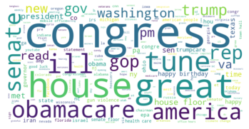

```
<wordcloud.wordcloud.WordCloud at 0x7fbb5b0efc40>
```

```python
from wordcloud import WordCloud

# generate string from themes
themes = df_themes['theme']
themes_combined = themes.apply(lambda x: ' '.join(x))
wc_text = themes_combined.to_string()

# plot word cloud
wc = WordCloud(width=800, height=400, background_color="white").generate(wc_text)
plt.figure()
plt.imshow(wc, interpolation="bilinear")
plt.axis("off")
plt.show()

# save as PNG image
wc.to_file('./themes_word_cloud.png')
```

# Cluster users

I cluster the users mainly based on their political views. In other words, their sentiments of some specific themes.

## Read data

```python
df_tweets = pd.read_pickle('./df_tweets_sentiment.pkl')
df_users = pd.read_pickle('./df_users_cleaned.pkl')
df_themes = pd.read_pickle('./df_themes.pkl')
```

## Extract text features

Extract these features from users' tweets:

- sentiment of theme: *polarity, subjectivity*
- frequency of theme: *count*

```python
themes = [
    'obamacare',
    'trump',
    'health',
    'medi',
    'russia',
    'israel',
    'iran',
    'tax',
    'climate',
]

df_features = pd.DataFrame()

for t in themes:
    # filter rows that contains 't' in the text
    df = df_tweets[
        df_tweets['text'].str.contains(t, case=False, regex=True)
    ].copy(deep=True)

    df.drop(
        ['created_at', 'favorite_count', 'id', 'retweet_count', 'text'],
        axis=1,
        inplace=True
    )

    # calculate mean polarity, mean subjectivity, and count
    df_agg = df.groupby(['user_id']).mean()
    df_agg['count'] = df.groupby(['user_id'])['polarity'].count()

    df_agg.rename(
        columns={
            'polarity': 'polarity_' + t,
            'subjectivity': 'subjectivity_' + t,
            'count': 'count_' + t
        },
        inplace=True
    )

    df_agg.reset_index(inplace=True)

    if df_features.empty:
        df_features = df_agg
    else:
        df_features = df_features.merge(df_agg, how='outer', on='user_id')

# add '(user) name' column
df_user_features = df_features.merge(df_users[['id', 'name']], how='left', left_on='user_id', right_on='id')
df_user_features.drop('id', axis=1, inplace=True)
```

```python
# show samples of df_user_features
df_user_features.sample(n=10, random_state=1)
```

|  | user_id | polarity_obamacare | subjectivity_obamacare | count_obamacare | polarity_trump | subjectivity_trump | count_trump | polarity_health | subjectivity_health | count_health | ... | polarity_iran | subjectivity_iran | count_iran | polarity_tax | subjectivity_tax | count_tax | polarity_climate | subjectivity_climate | count_climate | name |
| --- | --- | --- | --- | --- | --- | --- | --- | --- | --- | --- | --- | --- | --- | --- | --- | --- | --- | --- | --- | --- | --- |
| 244 | 246341769 | 0.157361 | 0.369187 | 47.0 | 0.143220 | 0.493061 | 21.0 | 0.148516 | 0.341974 | 32.0 | ... | -0.163542 | 0.428750 | 10.0 | 0.185078 | 0.345552 | 35.0 | 0.650000 | 0.666667 | 3.0 | Raúl R. Labrador |
| 132 | 73303753 | 0.001250 | 0.201250 | 10.0 | 0.244022 | 0.448329 | 32.0 | 0.219028 | 0.395476 | 21.0 | ... | 0.041594 | 0.281379 | 292.0 | -0.006313 | 0.199510 | 51.0 | -0.027778 | 0.322222 | 3.0 | Senator Bob Corker |
| 385 | 1883356866 | 0.004969 | 0.504825 | 14.0 | 0.064572 | 0.332606 | 9.0 | 0.000000 | 0.000000 | 3.0 | ... | NaN | NaN | NaN | 0.154081 | 0.381859 | 13.0 | 0.000000 | 0.000000 | 2.0 | Rep John Duncan Jr. |
| 133 | 74198348 | 0.020685 | 0.201670 | 35.0 | 0.187982 | 0.365813 | 11.0 | 0.079931 | 0.237980 | 28.0 | ... | 0.033937 | 0.281944 | 51.0 | 0.051262 | 0.255798 | 60.0 | NaN | NaN | NaN | Ted Poe |
| 480 | 14275291 | NaN | NaN | NaN | 0.069958 | 0.124983 | 54.0 | 0.188189 | 0.318355 | 48.0 | ... | 0.028896 | 0.155137 | 56.0 | 0.120278 | 0.382593 | 15.0 | 0.248102 | 0.402546 | 30.0 | Ileana Ros-Lehtinen |
| 438 | 3141213592 | -0.088616 | 0.387387 | 14.0 | 0.219139 | 0.456810 | 31.0 | 0.184258 | 0.355083 | 105.0 | ... | -0.037500 | 0.708333 | 2.0 | 0.048128 | 0.256454 | 17.0 | 0.000000 | 0.416667 | 3.0 | Governor Matt Bevin |
| 512 | 607332953 | NaN | NaN | NaN | 0.070833 | 0.154167 | 3.0 | 0.153512 | 0.327651 | 57.0 | ... | NaN | NaN | NaN | 0.061859 | 0.341564 | 57.0 | 0.053283 | 0.453535 | 6.0 | Governor Jim Justice |
| 119 | 47798449 | 0.121113 | 0.375311 | 42.0 | 0.000000 | 0.000000 | 1.0 | 0.177620 | 0.373476 | 73.0 | ... | 0.131738 | 0.401575 | 27.0 | 0.095550 | 0.321543 | 85.0 | 0.000000 | 0.200000 | 4.0 | Mimi Walters |
| 260 | 266133081 | 0.079091 | 0.310261 | 33.0 | 0.218750 | 0.354167 | 2.0 | 0.189466 | 0.373922 | 80.0 | ... | 0.022454 | 0.215741 | 12.0 | 0.127578 | 0.350646 | 121.0 | 0.000000 | 0.000000 | 1.0 | Dean Heller |
| 328 | 1058345042 | 0.024588 | 0.254902 | 42.0 | 0.141667 | 0.200000 | 5.0 | 0.095580 | 0.220611 | 30.0 | ... | -0.041667 | 0.541667 | 3.0 | 0.114811 | 0.307405 | 68.0 | NaN | NaN | NaN | Congressman Tom Rice |

10 rows × 29 columns

```python
# save df_user_features as pickle file
df_user_features.to_pickle('./df_features.pkl')
```

## K-Means Clustering

### Determine the optimal number of clusters

Use the [elbow method](https://www.datanovia.com/en/lessons/determining-the-optimal-number-of-clusters-3-must-know-methods/):

1. Compute clustering algorithm (e.g., k-means clustering) for different values of k. For instance, by varying k from 1 to 10 clusters.
2. For each k, calculate the error sum of squares (SSE).
3. Plot the curve of SSE according to the number of clusters k.
4. The location of a bend (knee) in the plot is generally considered as an indicator of the appropriate number of clusters.

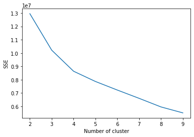

```python
from sklearn.cluster import KMeans

sse = dict()

data = df_user_features.drop(['user_id', 'name'], axis=1).fillna(0)

for k in range(2, 10):
    kmeans = KMeans(n_clusters=k, max_iter=1000).fit(data)
    sse[k] = kmeans.inertia_

plt.figure()
plt.plot(list(sse.keys()), list(sse.values()))
plt.xlabel("Number of cluster")
plt.ylabel("SSE")
plt.show()
```

The picture above indicates that the optimal number of clusters is 4.

### Cluster users based on their political views

Create a *cluster* column that stores the cluster labels of users.

Number of clusters = 4

```python
# fit data to clustering model and get cluster labels
kmeans = KMeans(n_clusters=4, max_iter=1000).fit(data)
df_user_features['cluster'] = kmeans.labels_
```

```python
df_cluster = df_user_features[['user_id', 'name', 'cluster']]
df_cluster.sample(n=10, random_state=0)
```

|  | user_id | name | cluster |
| --- | --- | --- | --- |
| 103 | 33655490 | Dennis Ross | 2 |
| 179 | 172858784 | Senator Tim Kaine | 0 |
| 474 | 817138492614524928 | Ted Budd | 3 |
| 345 | 1072008757 | Rep. Chris Stewart | 3 |
| 132 | 73303753 | Senator Bob Corker | 3 |
| 236 | 240760644 | Rep. Paul Gosar, DDS | 3 |
| 118 | 47747074 | Brian Schatz | 1 |
| 75 | 23124635 | Rep. Tom Cole | 3 |
| 480 | 14275291 | Ileana Ros-Lehtinen | 3 |
| 395 | 2852998461 | Rep. Bruce Westerman | 3 |

```python
# save df_cluster as pickle file
df_cluster.to_pickle('./df_cluster.pkl')
```

## Interpret data with clusters

### About climate

Users in cluster 1 are highly concerned about climate change.

Their sentiments are slightly positive. So they might think the climate is becoming better or people are actively improving the climate.

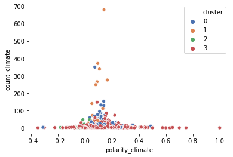

```python
sns.scatterplot(
    data=df_user_features,
    x='polarity_climate',
    y='count_climate',
    hue='cluster',
    palette='deep'
)
```

### About Obamacare

Most users in cluster 2 frequently post tweets about Obamacare and hold slightly positive attitudes. So they are likely to be supporters of Obamacare.

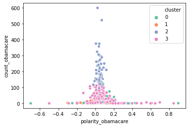

```python
sns.scatterplot(
    data=df_user_features,
    x='polarity_obamacare',
    y='count_obamacare',
    hue='cluster',
    palette='Set2'
)
```

# Recommendations and Actions

If my client wants to influence the legislation related to a theme, he/she is recommended to take the following steps:

1. Use the *df_user_features* datafram, draw a scatter plot of "count - polarity" for the specific theme.
2. Find the cluster of users that mostly concerned about the theme. In other words, users in that cluster should have high counts in the scatter plot.
   - If the majority of the cluster lies in the positive polarity field, then its members hold positive views of the theme.
   - If the majority of the cluster lies in the negative polarity field, then its members hold negative views of the theme.
3. In the df_users dataframe, filter users in your target cluster, and then descendingly sort them by *follower_count*. Users on the top are most influential.
4. Lobby those influential users you have found.